# Clustering

Alexander McLain

2025-11-04

```r
knitr::opts_chunk$set(
  echo = TRUE, message = FALSE, warning = FALSE, cache = TRUE,
  fig.width = 7, fig.height = 5
)
library(ISLR)
library(tidyverse)
library(cluster)
library(factoextra)
library(mclust)
library(NbClust)
library(fpc)
library(ggplot2)
library(GGally)
```

# Introduction

This report explores several clustering techniques—K-means, PAM, Gaussian Mixture Models (GMM), and Hierarchical Clustering—applied to the NCI60 gene expression dataset (from ISLR). We will also evaluate the optimal number of clusters using both Elbow and Gap Statistic methods.

⸻

Load and Prepare the Data

```r
data("NCI60")
X <- NCI60$data
dim(X)
```

```
## [1]   64 6830
```

```r
# Standardize features
X.scaled <- scale(X)
```

⸻

## Choosing the Number of Clusters

### 1. Elbow Method

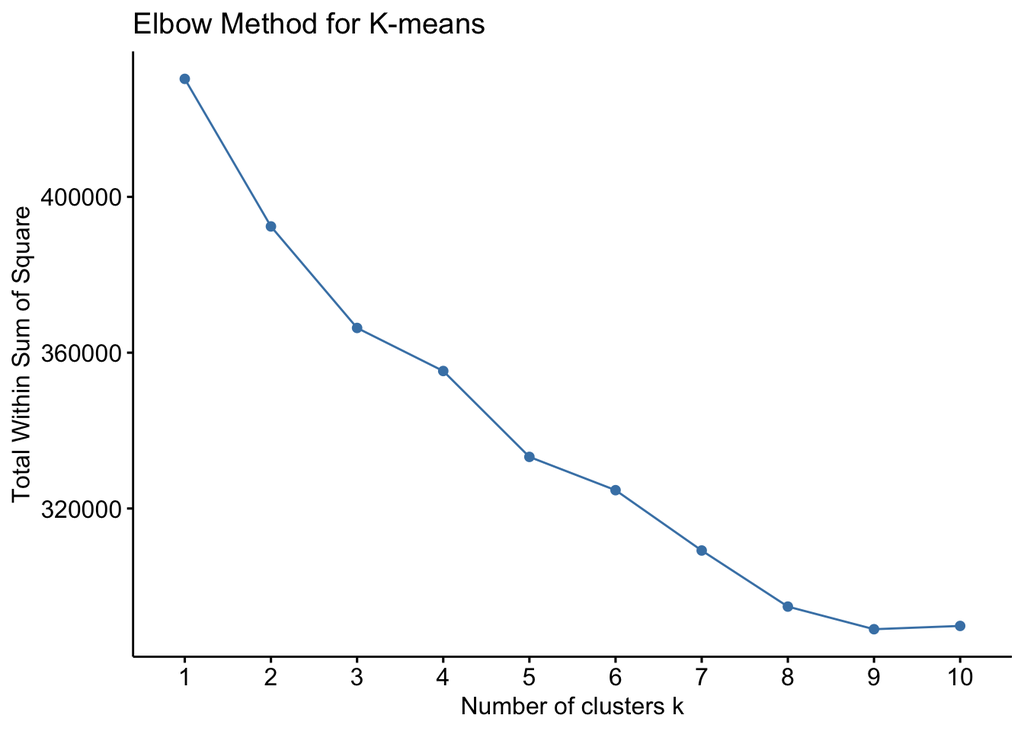

```r
fviz_nbclust(X.scaled, kmeans, method = "wss") +
  labs(title = "Elbow Method for K-means")
```

### 2. Gap Statistic

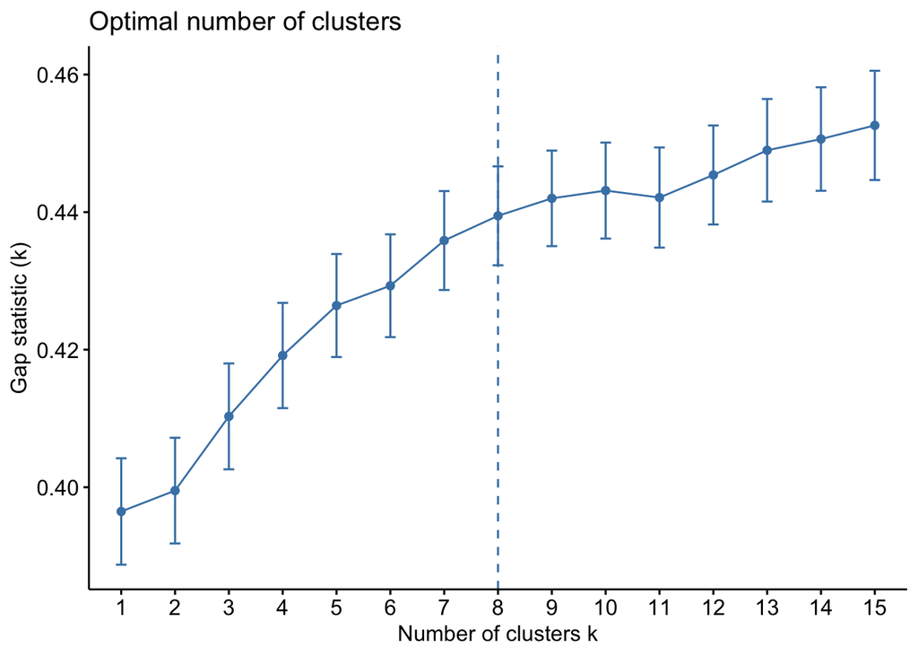

```r
set.seed(123)
gap_kmeans <- clusGap(X.scaled, FUN = kmeans, nstart = 25, K.max = 15, B = 50)
fviz_gap_stat(gap_kmeans)
```

⸻

# K-means Clustering

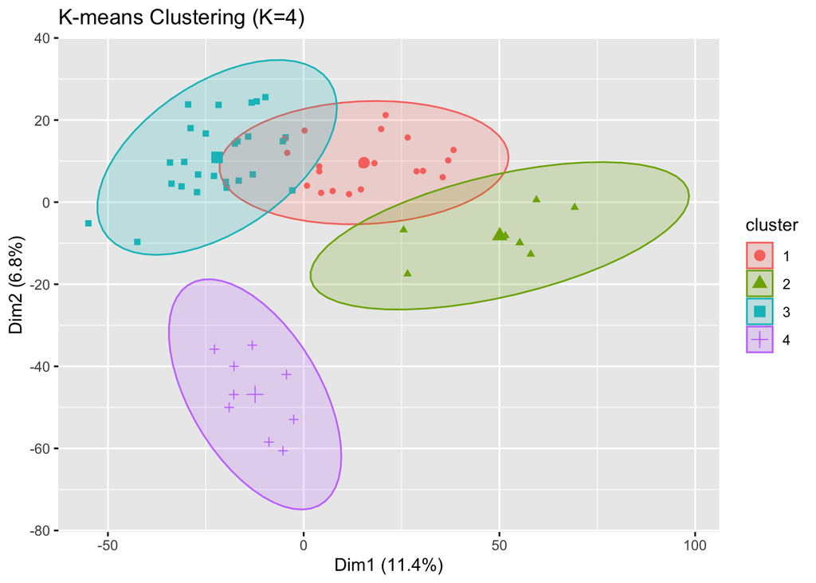

```r
set.seed(123)
km_res <- kmeans(X.scaled, centers = 4, nstart = 25)
fviz_cluster(km_res, data = X.scaled, geom = "point", ellipse.type = "norm") +
  labs(title = "K-means Clustering (K=4)")
```

```r
table(NCI60$labs, km_res$cluster)
```

```
##
##               1 2 3 4
##   BREAST      2 0 3 2
##   CNS         0 0 5 0
##   COLON       7 0 0 0
##   K562A-repro 0 1 0 0
##   K562B-repro 0 1 0 0
##   LEUKEMIA    0 6 0 0
##   MCF7A-repro 1 0 0 0
##   MCF7D-repro 1 0 0 0
##   MELANOMA    0 0 1 7
##   NSCLC       5 0 4 0
##   OVARIAN     3 0 3 0
##   PROSTATE    1 0 1 0
##   RENAL       0 0 9 0
##   UNKNOWN     0 0 1 0
```

# Silhouette Width

For each observation i, the silhouette width measures how well it fits within its assigned cluster compared to other clusters. It’s defined as:

$$s(i) = \frac{b(i) - a(i)}{\max\{a(i),
b(i)\}}$$

where:

• $a(i)$: the average distance from i to all other points in its own cluster (cohesion).

• $b(i)$: the lowest average distance from i to all points in another cluster (separation).

## Average Silhouette Width

The average silhouette width across all observations gives an overall summary of clustering quality:

$$S = \frac{1}{n} \sum_{i=1}^n
s(i)$$

• $S$ ranges between $-1$ and $+1$.

• Higher $S$ means better-defined and more separated clusters.

• When comparing cluster solutions with different $K$ values, choose the $K$ that maximizes $S$.

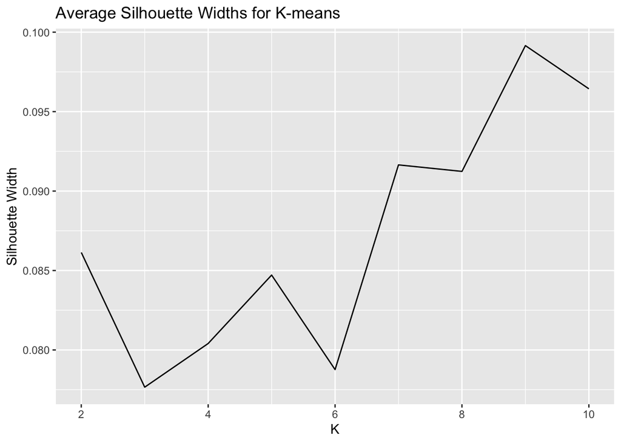

```r
sil_widths <- sapply(2:10, function(k){
  km <- kmeans(X.scaled, centers = k, nstart = 25)
  mean(silhouette(km$cluster, dist(X.scaled))[, 3])
})
qplot(2:10, sil_widths, geom="line") +
  labs(title="Average Silhouette Widths for K-means", x="K", y="Silhouette Width")
```

```
##   cluster size ave.sil.width
## 1       1   20          0.07
## 2       2    8          0.10
## 3       3   27          0.05
## 4       4    9          0.17
```

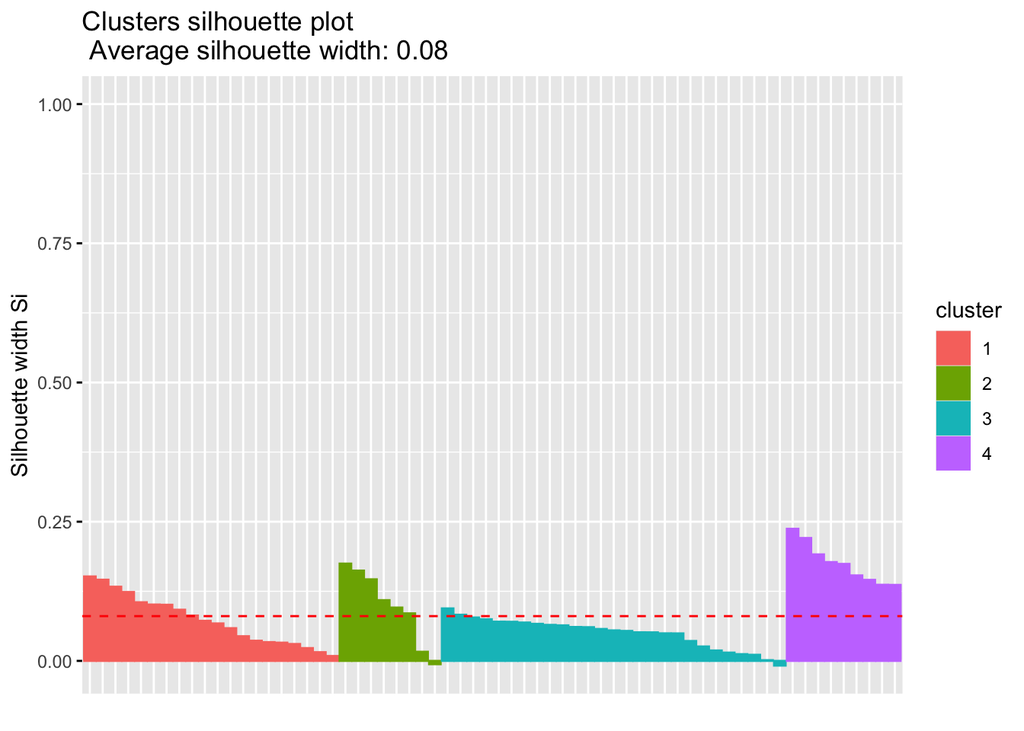

```r
fviz_silhouette(silhouette(km_res$cluster, dist(X.scaled)))
```

⸻

# Partitioning Around Medoids (PAM)

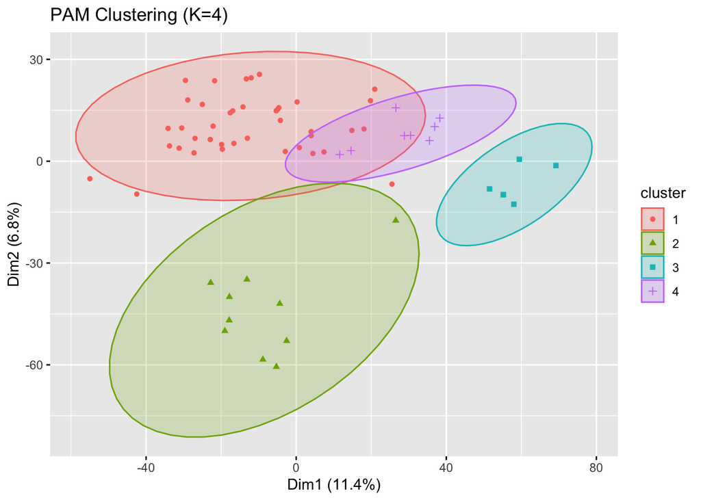

```r
pam_res <- pam(X.scaled, k = 4, metric = "euclidean")
fviz_cluster(pam_res, data = X.scaled, geom = "point", ellipse.type = "norm") +
  labs(title = "PAM Clustering (K=4)")
```

```r
table(NCI60$labs, pam_res$clustering)
```

```
##
##               1 2 3 4
##   BREAST      3 2 0 2
##   CNS         5 0 0 0
##   COLON       4 0 0 3
##   K562A-repro 0 0 1 0
##   K562B-repro 0 0 1 0
##   LEUKEMIA    1 1 4 0
##   MCF7A-repro 0 0 0 1
##   MCF7D-repro 0 0 0 1
##   MELANOMA    1 7 0 0
##   NSCLC       8 0 0 1
##   OVARIAN     6 0 0 0
##   PROSTATE    2 0 0 0
##   RENAL       9 0 0 0
##   UNKNOWN     1 0 0 0
```

```
##   cluster size ave.sil.width
## 1       1   40          0.05
## 2       2   10          0.14
## 3       3    6          0.18
## 4       4    8          0.10
```

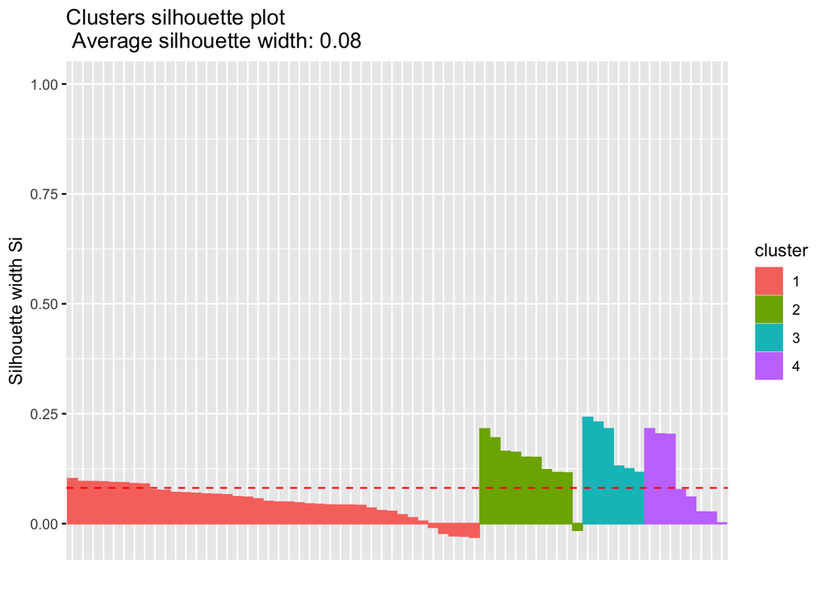

```r
fviz_silhouette(pam_res)
```

⸻

# Gaussian Mixture Model (Model-based Clustering)

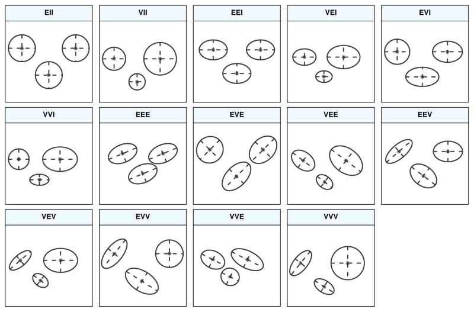

Ellipses of isodensity for each of the 14 Gaussian models obtained by eigen-decomposition in case of three groups in two dimensions.

```r
gmm_res <- Mclust(X.scaled, G = 1:10)
summary(gmm_res)
```

```
## ----------------------------------------------------
## Gaussian finite mixture model fitted by EM algorithm
## ----------------------------------------------------
##
## Mclust VII (spherical, varying volume) model with 3 components:
##
##  log-likelihood  n    df      BIC      ICL
##       -580289.8 64 20495 -1245816 -1245816
##
## Clustering table:
##  1  2  3
## 35 20  9
```

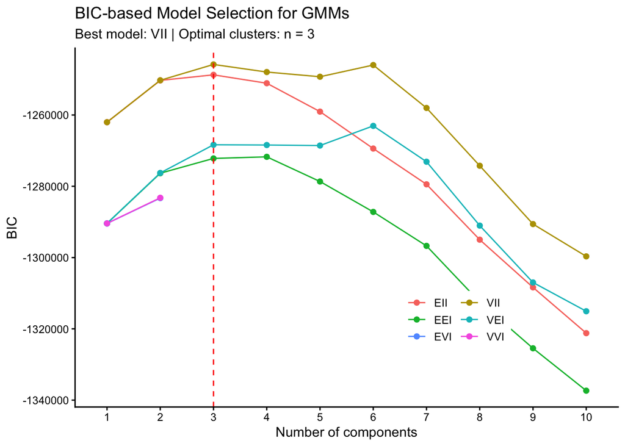

```r
fviz_mclust(gmm_res, "BIC") +
  labs(title = "BIC-based Model Selection for GMMs")
```

```r
table(NCI60$labs, gmm_res$classification)
```

```
##
##               1 2 3
##   BREAST      3 2 2
##   CNS         5 0 0
##   COLON       0 7 0
##   K562A-repro 0 1 0
##   K562B-repro 0 1 0
##   LEUKEMIA    0 6 0
##   MCF7A-repro 0 1 0
##   MCF7D-repro 0 1 0
##   MELANOMA    1 0 7
##   NSCLC       8 1 0
##   OVARIAN     6 0 0
##   PROSTATE    2 0 0
##   RENAL       9 0 0
##   UNKNOWN     1 0 0
```

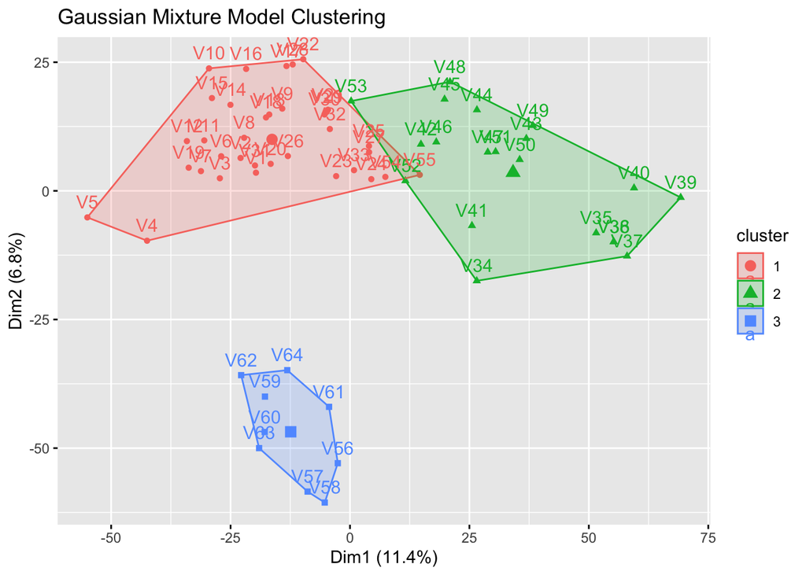

```r
fviz_cluster(list(data = X.scaled, cluster = gmm_res$classification)) +
  labs(title = "Gaussian Mixture Model Clustering")
```

⸻

# Hierarchical Clustering

## 1. Compute Dissimilarity Matrix

```r
d <- dist(X.scaled, method = "euclidean")
hc_complete <- hclust(d, method = "complete")
hc_average  <- hclust(d, method = "average")
hc_single   <- hclust(d, method = "single")
```

## 2. Dendrograms

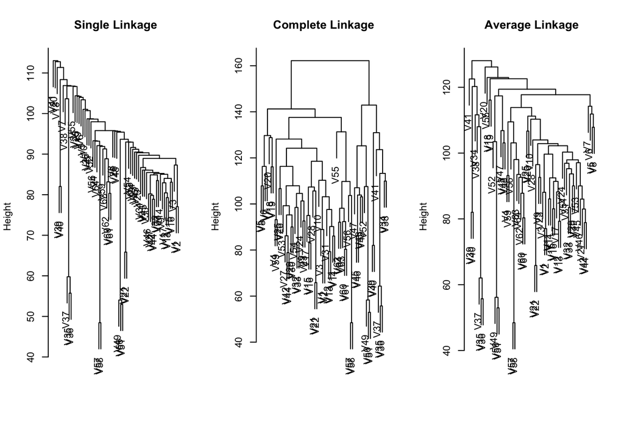

```r
par(mfrow = c(1,3))
plot(hc_single, main = "Single Linkage", xlab = "", sub = "")
plot(hc_complete, main = "Complete Linkage", xlab = "", sub = "")
plot(hc_average, main = "Average Linkage", xlab = "", sub = "")
```

## 3. Cut Tree and Visualize

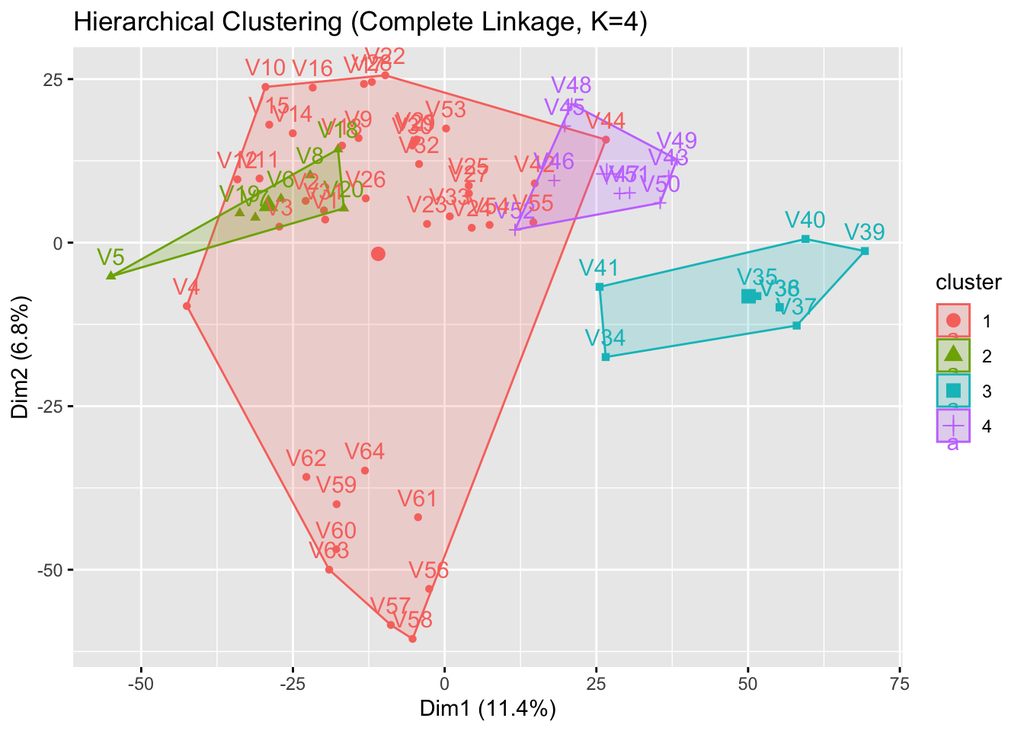

```r
cut_complete <- cutree(hc_complete, k = 4)
fviz_cluster(list(data = X.scaled, cluster = cut_complete)) +
  labs(title = "Hierarchical Clustering (Complete Linkage, K=4)")
```

```r
table(NCI60$labs,cut_complete)
```

```
##              cut_complete
##               1 2 3 4
##   BREAST      2 3 0 2
##   CNS         3 2 0 0
##   COLON       2 0 0 5
##   K562A-repro 0 0 1 0
##   K562B-repro 0 0 1 0
##   LEUKEMIA    0 0 6 0
##   MCF7A-repro 0 0 0 1
##   MCF7D-repro 0 0 0 1
##   MELANOMA    8 0 0 0
##   NSCLC       8 1 0 0
##   OVARIAN     6 0 0 0
##   PROSTATE    2 0 0 0
##   RENAL       8 1 0 0
##   UNKNOWN     1 0 0 0
```

⸻

# Comparing Methods

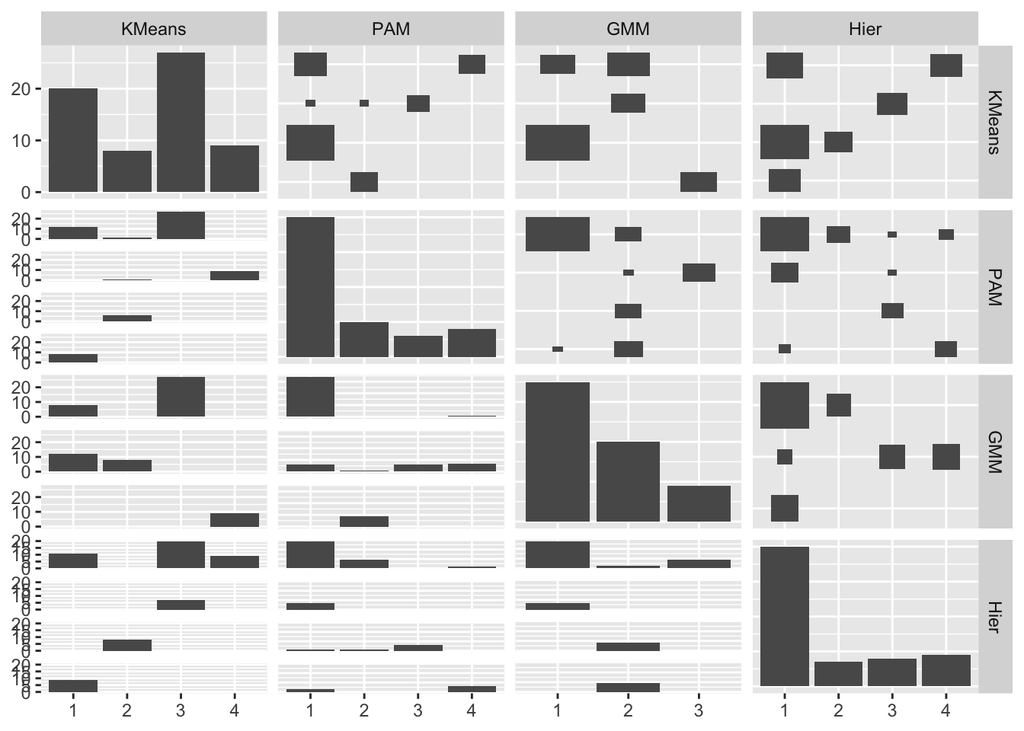

```r
clust_compare <- tibble(
  KMeans = km_res$cluster,
  PAM = pam_res$clustering,
  GMM = gmm_res$classification,
  Hier = cut_complete
)

GGally::ggpairs(clust_compare %>% mutate_all(as.factor))
```

⸻

Selecting the Best Number of Clusters

• Elbow Method: visual inspection of total within-cluster sum of squares.

• Silhouette width: can be used to confirm cluster separation.

⸻

# Summary

- **K-means** Fast, easy to interpret, but sensitive to scaling, outliers
- **PAM** Robust to outliers, but slower on large datasets.
- **GMM** Captures overlapping/elliptical clusters, but requires distributional assumptions.
- **Hierarchical** Dendrogram visualization, no K needed a priori, but is computationally intensive.